# Assignment 1 ST464/ST684

madhusudan 20250509

12:34:27 AM 26 February, 2021

Question 1 (a)

```r
x<-matrix(c(-3,5,-4,0,4,-1,-2,3,2,-5),ncol=2)
x
```

```
##      [,1] [,2]
## [1,]   -3   -1
## [2,]    5   -2
## [3,]   -4    3
## [4,]    0    2
## [5,]    4   -5
```

```r
eud <- as.matrix(dist(x, method = "euclidean"))
eud2 <- eud*eud
eud2
```

```
##    1   2   3  4   5
## 1  0  65  17 18  65
## 2 65   0 106 41  10
## 3 17 106   0 17 128
## 4 18  41  17  0  65
## 5 65  10 128 65   0
```

#### Question 4

```r
# change to eval=T
# place the downloaded csv file in the same folder as this Rmd file.
w <- read.csv("C:/Users/Madhusudan/Desktop/Learning/Maynooth University/Semester2/ST684/Assignment/worldhappiness2019.csv")
names(w)<- c( "Rank", "Country", "Score", "GDP", "Family", "Life", "Freedom", "Generosity", "Trust")
rownames(w)<- w$Country
wscores <- w[,-(1:3)]
```

```r
cor(wscores)
```

```
##                    GDP      Family        Life   Freedom  Generosity     Trust
## GDP         1.00000000  0.75490573  0.83546212 0.3790791 -0.07966231 0.2989198
## Family      0.75490573  1.00000000  0.71900946 0.4473332 -0.04812645 0.1818995
## Life        0.83546212  0.71900946  1.00000000 0.3903948 -0.02951086 0.2952828
## Freedom     0.37907907  0.44733316  0.39039478 1.0000000  0.26974181 0.4388433
## Generosity -0.07966231 -0.04812645 -0.02951086 0.2697418  1.00000000 0.3265375
## Trust       0.29891985  0.18189946  0.29528281 0.4388433  0.32653754 1.0000000
```

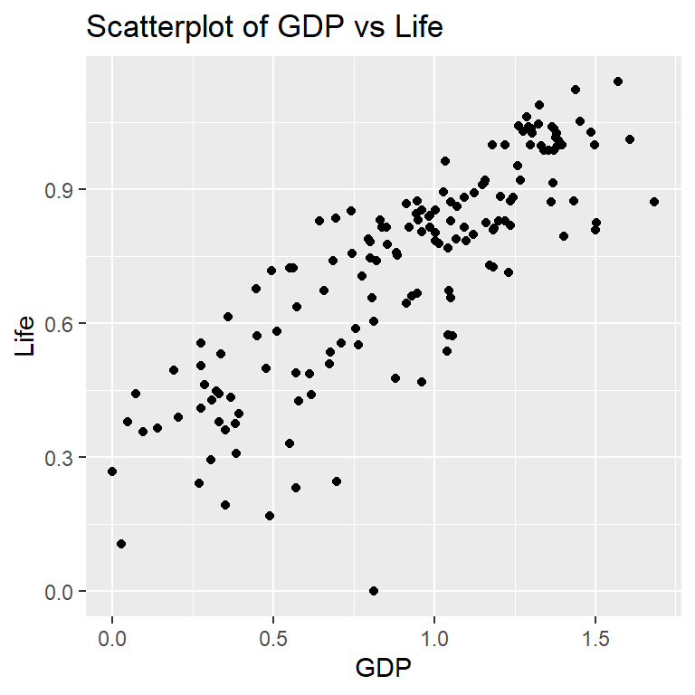

```r
#we see that life and GDP is having highest correlation (0.8354)
library(ggplot2)
ggplot(data=wscores, aes(x=GDP, y=Life))+geom_point() +
      labs(title = "Scatterplot of GDP vs Life")
```

```r
head(wscores)
```

```
##               GDP Family  Life Freedom Generosity Trust
## Finland     1.340  1.587 0.986   0.596      0.153 0.393
## Denmark     1.383  1.573 0.996   0.592      0.252 0.410
## Norway      1.488  1.582 1.028   0.603      0.271 0.341
## Iceland     1.380  1.624 1.026   0.591      0.354 0.118
## Netherlands 1.396  1.522 0.999   0.557      0.322 0.298
## Switzerland 1.452  1.526 1.052   0.572      0.263 0.343
```

```r
print(wscores[wscores$Life==0,])
```

```
##             GDP Family Life Freedom Generosity Trust
## Swaziland 0.811  1.149    0   0.313      0.074 0.135
```

The pair of variables with the highest correlation are GDP and Life. The outlying country on this graph is Swaziland.

```r
#Euclidean matrix of wscores - no standardistaion
e <- dist(wscores,method="euclidean")
head(e)
```

```
## [1] 0.1106842 0.2009229 0.3473039 0.2159560 0.1892010 0.1631502
```

```r
##countries clustering (Average linkage)
clust <- hclust(e,"average")
clust
```

```
##
## Call:
## hclust(d = e, method = "average")
##
## Cluster method   : average
## Distance         : euclidean
## Number of objects: 156
```

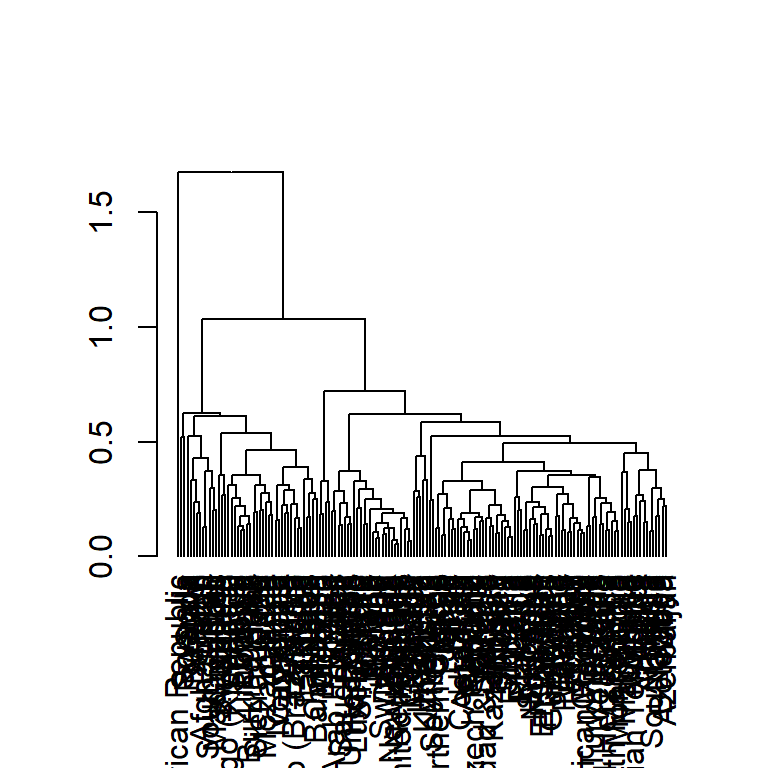

```r
#Dendrogram of clustering
d <- as.dendrogram(clust)
plot(d)
```

```r
#dividing into 3 clusters
c <- cutree(clust, 3)
table(c)
```

```
## c
##   1   2   3
## 111  44   1
```

```r
#Checking which clusters are having highest score
source('C:/Users/Madhusudan/Desktop/Learning/Maynooth University/Semester2/ST684/Assignment/sumPartition.R')
ws <- sumPartition(wscores,c)
```

```
## Final Partition
##
## Number of clusters  3
##
##           N.obs Within.clus.SS Ave.dist..Centroid Max.dist.centroid
## Cluster 1   111      16.679440          0.3618240         0.7628128
## Cluster 2    44       6.145732          0.3505806         0.6628750
## Cluster 3     1       0.000000          0.0000000         0.0000000
##
##
## Cluster centroids
##
##            Cluster 1 Cluster 2 Cluster 3 Grand centrd
## GDP        1.11018   0.4078864 0.026     0.9051474
## Family     1.34836   0.88425   0         1.208814
## Life       0.8471712 0.43175   0.105     0.7252436
## Freedom    0.4175405 0.3333864 0.225     0.3925705
## Generosity 0.1738829 0.2113636 0.235     0.1848462
## Trust      0.1148649 0.1015682 0.035     0.1106026
##
##
## Distances between Cluster centroids
##
##           Cluster 1 Cluster 2 Cluster 3
## Cluster 1 0.0000000 0.9433204  1.895132
## Cluster 2 0.9433204 0.0000000  1.025299
## Cluster 3 1.8951322 1.0252992  0.000000
```

```r
#looking at country from cluster-wise
wsnew <- wscores
wsnew$cluster <- factor(c)
wsnew$country <- rownames(wsnew)
head(wsnew)
```

```
##               GDP Family  Life Freedom Generosity Trust cluster     country
## Finland     1.340  1.587 0.986   0.596      0.153 0.393       1     Finland
## Denmark     1.383  1.573 0.996   0.592      0.252 0.410       1     Denmark
## Norway      1.488  1.582 1.028   0.603      0.271 0.341       1      Norway
## Iceland     1.380  1.624 1.026   0.591      0.354 0.118       1     Iceland
## Netherlands 1.396  1.522 0.999   0.557      0.322 0.298       1 Netherlands
## Switzerland 1.452  1.526 1.052   0.572      0.263 0.343       1 Switzerland
```

```r
#Ireland
wsire <- wsnew[wsnew$country=="Ireland",]
wsire
```

```
##           GDP Family  Life Freedom Generosity Trust cluster country
## Ireland 1.499  1.553 0.999   0.516      0.298  0.31       1 Ireland
```

```r
#India
wsind <- wsnew[wsnew$country=="India",]
wsind
```

```
##         GDP Family  Life Freedom Generosity Trust cluster country
## India 0.755  0.765 0.588   0.498        0.2 0.085       2   India
```

The cluster sizes are 111, 44 and 1 for cluster 1,2 and 3 respectively.

Ireland belongs to cluster 1.

India belongs to cluster 2.

Cluster 1 has the highest Family score.

Cluster 1 has the highest scores overall.

```r
library(GGally)
head(wsnew)
```

```
##               GDP Family  Life Freedom Generosity Trust cluster     country
## Finland     1.340  1.587 0.986   0.596      0.153 0.393       1     Finland
## Denmark     1.383  1.573 0.996   0.592      0.252 0.410       1     Denmark
## Norway      1.488  1.582 1.028   0.603      0.271 0.341       1      Norway
## Iceland     1.380  1.624 1.026   0.591      0.354 0.118       1     Iceland
## Netherlands 1.396  1.522 0.999   0.557      0.322 0.298       1 Netherlands
## Switzerland 1.452  1.526 1.052   0.572      0.263 0.343       1 Switzerland
```

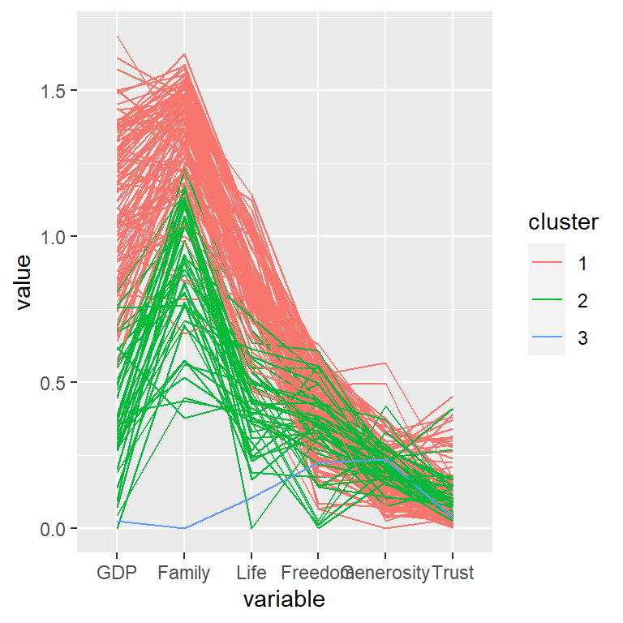

```r
ggparcoord(wsnew, columns = 1:6, groupColumn = "cluster", scale= "globalminmax")
```

```r
set.seed(123)
km <- kmeans(wscores, 3, nstart = 10)
km$centers
```

```
##         GDP    Family      Life   Freedom Generosity      Trust
## 1 1.3341875 1.4569375 0.9596458 0.4763542  0.2004375 0.17395833
## 2 0.9368281 1.2612500 0.7605000 0.3839375  0.1573750 0.07090625
## 3 0.3910227 0.8618636 0.4182500 0.3137273  0.2077955 0.09922727
```

```r
table(km$cluster)
```

```
##
##  1  2  3
## 48 64 44
```

AS we see that there are three groups and there are plentry of countries in each group so There are no outlier countries

```r
ws_km <- wscores
#creating new column as per factor of kmeans
ws_km$cluster <- factor(km$cluster)
#check new df once
head(ws_km)
```

```
##               GDP Family  Life Freedom Generosity Trust cluster
## Finland     1.340  1.587 0.986   0.596      0.153 0.393       1
## Denmark     1.383  1.573 0.996   0.592      0.252 0.410       1
## Norway      1.488  1.582 1.028   0.603      0.271 0.341       1
## Iceland     1.380  1.624 1.026   0.591      0.354 0.118       1
## Netherlands 1.396  1.522 0.999   0.557      0.322 0.298       1
## Switzerland 1.452  1.526 1.052   0.572      0.263 0.343       1
```

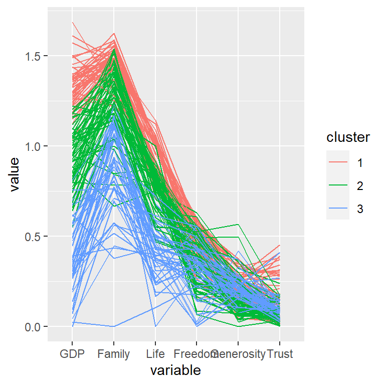

```r
#creating plot
ggparcoord(ws_km, columns = 1:6, groupColumn = "cluster", scale= "globalminmax")
```

Cluster 1 (red) has the highest Family score. Cluster 1 (red) has the highest scores overall.

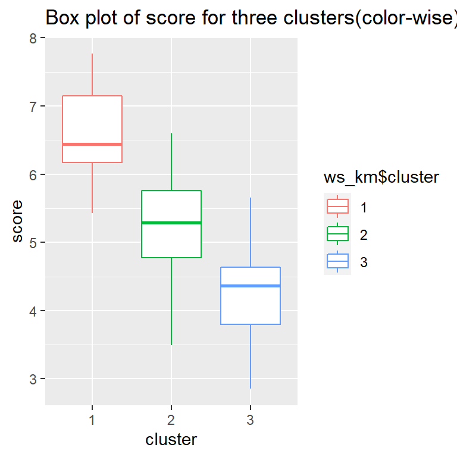

```r
#g
ws_km$score <- w$Score
ggplot(ws_km, aes(x=cluster, y=score, color=ws_km$cluster)) + geom_boxplot() +
  labs(title = "Box plot of score for three clusters(color-wise)")
```

We can clearly see that cluster 1 countries are having best scores i.e. they are the happiest while cluster 2 is in middle and cluster 3 countries(least score) are the lease happy countries.